# Computing Gfactor based on cognitive scores based on NIH toolbox and Pearson scores of Rey auditory verbal learning test

Yue Wang, Narun Pat

05 Jul, 2023

# 1 Setting up the environment

## 1.1 Reset workspace and load libraries

```r
rm(list=ls())
gc()
```

Load libraries

```r
library(tidyverse)
library(qgraph)
library(pander)
library(summarytools)
library(sjPlot)
library(sjmisc)
library(sjlabelled)
library(tidymodels)
library(knitr)
library(extrafont)
## for poisson class of elastic net
library(poissonreg)
```

## 1.2 Setting up paths

This analysis uses ABCD Release 4

```r
#ABCD3Fold <- '/Volumes/wd/ABCD3/'
#ABCD3Fold <-"~/OneDrive - University of Otago/ABCD3/"
#ABCD4Fold <-"/media/Data/ABCD/ABCD4/"
ABCD4Fold <-"/Volumes/Data/ABCD/ABCD4/"
#ABCD4Fold <- "//np-qnapa/Data/ABCD/ABCD4/"
#setwd(paste0(ABCD3Fold, "Analysis/CognitionP"))
dataFold <- paste0(ABCD4Fold, "ABCD4SQL/")

#ABCD3Fold <-"/media/Data/ABCD/ABCD3/"
ABCD3Fold <-"/Volumes/Data/ABCD/ABCD3/"
utilFold <- paste0(ABCD3Fold, "Analysis/utilFunc/")

#NDAfold = "/media/Data/ABCD/ABCD4/ABCDStudyNDA/"
NDAfold = "/Volumes/Data/ABCD/ABCD4/ABCDStudyNDA/"


#scriptfold = "/media/Data/Yue script/"
scriptfold = "/Volumes/Data/Yue script/"

gene_fold <- paste0(ABCD4Fold, "RicPGS/RicFIles20_Feb_2022/abcd-release-3.0_chrall_0.8-mac5-hg19-eur-qc-v9/")
source(paste0(scriptfold,"stacking_gfactor_modelling/r_functions.R"))
```

Set up parallel library

```r
# parallel for ubuntu
doParallel::registerDoParallel(cores=30)

## this one works for ubuntu but slow
#library(doFuture)
#registerDoFuture()
#plan(multicore(workers = 30))

### parallel for windows

#library(doFuture)
#registerDoFuture()
#plan(multisession(workers = 30))
```

# 2 Loading data

## 2.1 site information

```r
###loading site and scanner information
Siteinfo <-tibble::as_tibble(read.csv(paste0(dataFold, "ABCD_LT01_DATA_TABLE.csv")))
```

Change the wrong site manually based on the: “Release Notes: Adolescent Brain Cognitive Development Study ℠ (ABCD Study ® ) Data Release 4.0 Changes and Known Issues”

Only fixed the baseline and two year followup that is used in the analysis

```r
Siteinfo_fixed <- Siteinfo

site_fix <- readRDS(paste0(scriptfold,'Common_psy_gene_brain_all/saved_outputs/site_fix', '.RData'))

for(i in 1:dim(site_fix)[1]){
  fix_site_id  <- site_fix$SUBJECTKEY[i]
  fix_site_event <- site_fix$EVENTNAME[i]
  fix_site <- site_fix$SITE_ID_L[i]
  Siteinfo_fixed$SITE_ID_L[which(Siteinfo_fixed$SUBJECTKEY== fix_site_id& Siteinfo_fixed$EVENTNAME == fix_site_event)] <- fix_site
}

Siteinfo <-Siteinfo_fixed
```

## 2.2 Cognition

### 2.2.1 Load neuro cognitive measures

```r
NIH_TB <-as_tibble(read.csv(paste0(dataFold,"ABCD_TBSS01_DATA_TABLE.csv")))
CashChoice <-as_tibble(read.csv(paste0(dataFold,"CCT01_DATA_TABLE.csv")))
LittleMan <-as_tibble(read.csv(paste0(dataFold,"LMTP201_DATA_TABLE.csv")))
Pearson <-as_tibble(read.csv(paste0(dataFold,"ABCD_PS01_DATA_TABLE.csv")))
#ABCD Youth Delay Discounting Scores    only used in the follow up data
DelayDis <-as_tibble(read.csv(paste0(dataFold,"ABCD_YDDSS01_DATA_TABLE.csv")))
#ABCD Emotional Stroop Task only used in the follow up data
EmoStroop <-as_tibble(read.csv(paste0(dataFold,"ABCD_YEST01_DATA_TABLE.csv")))
#ABCD Game of Dice Task abcd_gdss01 only used in the follow up data
GameOfDice <-as_tibble(read.csv(paste0(dataFold,"ABCD_GDSS01_DATA_TABLE.csv")))
#ABCD Social Influence Task abcd_siss01 only used in the follow up data
SocialInfluence <-as_tibble(read.csv(paste0(dataFold,"ABCD_SISS01_DATA_TABLE.csv")))

vision_idx <- as_tibble(read.csv(paste0(dataFold,"ABCD_SVS01_DATA_TABLE.CSV"))) %>%
  mutate(visionProb = ifelse(SNELLEN_VA_Y == 0 | SNELLEN_VA_Y == 1 | VIS_FLG == 2, 1, 0))

#vision_idx %>% select(SNELLEN_VA_Y, VIS_FLG, visionProb) %>%  arrange(SNELLEN_VA_Y)
```

### 2.2.2 sum cognition

```r
sumCog <- plyr::join_all(list(NIH_TB, CashChoice, LittleMan, Pearson, vision_idx),
               by=c('SUBJECTKEY','EVENTNAME'), type='full') %>%
  select(SUBJECTKEY,EVENTNAME,
         NIHTBX_FLANKER_UNCORRECTED, NIHTBX_CARDSORT_UNCORRECTED, NIHTBX_PATTERN_UNCORRECTED,
         NIHTBX_PICVOCAB_UNCORRECTED, NIHTBX_READING_UNCORRECTED, NIHTBX_PICTURE_UNCORRECTED,
         PEA_RAVLT_LD_TRIAL_VII_TC, NIHTBX_LIST_UNCORRECTED, LMT_SCR_PERC_CORRECT, PEA_WISCV_TRS,
         NIHTBX_FLUIDCOMP_UNCORRECTED, NIHTBX_CRYST_UNCORRECTED, NIHTBX_TOTALCOMP_UNCORRECTED, visionProb)
```

### 2.2.3 Detect the observations with vision issues

```r
data_removed <- vision_idx %>% filter(SNELLEN_VA_Y == 0 | SNELLEN_VA_Y == 1 | VIS_FLG == 2)

removed_subj <- data_removed$SUBJECTKEY
length(removed_subj)
```

```
## [1] 58
```

# 3 Compute and process gfactor

Here are the cognition tasks selected to compute gfactor:

NIH Toolbox Picture Vocabulary Test Age 3+

NIH Toolbox Oral Reading Recognition Test Age 3+

NIH Toolbox Flanker Inhibitory Control and Attention Test Ages 8-11

NIH Toolbox Pattern Comparison Processing Speed Test Age 7+

NIH Toolbox Picture Sequence Memory Test Age 8+

Pearson Scores: Rey Auditory Verbal Learning Test

```r
TaskDVs1Batch = c("NIHTBX_PICVOCAB_UNCORRECTED",
                  "NIHTBX_READING_UNCORRECTED",
              "NIHTBX_FLANKER_UNCORRECTED",
              "NIHTBX_PATTERN_UNCORRECTED",
              "NIHTBX_PICTURE_UNCORRECTED",
               "PEA_RAVLT_LD_TRIAL_VII_TC")


subj_info <-  c("SUBJECTKEY","EVENTNAME","SITE_ID_L")


sumCog_select <- sumCog %>%
  select(all_of(TaskDVs1Batch),all_of(c("SUBJECTKEY","EVENTNAME" )))

subj_info <- c("SUBJECTKEY","EVENTNAME","SITE_ID_L")

sumCog_select <- left_join(sumCog_select,Siteinfo,by =c("SUBJECTKEY","EVENTNAME"))%>%
  drop_na(SITE_ID_L) %>%
  filter(SITE_ID_L != "site22")%>%
  select(all_of(TaskDVs1Batch),all_of(subj_info))
```

### 3.0.1 Remove the subjects due to vision

```r
sumCog_select <- sumCog_select %>% filter(!SUBJECTKEY %in% removed_subj)
```

## 3.1 Compute and scale gfactor

### 3.1.1 The CFA model for gfactor

```r
NeuroCog2ndOrder <-'
Language =~ NIHTBX_PICVOCAB_UNCORRECTED + NIHTBX_READING_UNCORRECTED
CognitiveFlexibity =~ NIHTBX_FLANKER_UNCORRECTED + NIHTBX_PATTERN_UNCORRECTED
MemoryRecall =~ NIHTBX_PICTURE_UNCORRECTED + PEA_RAVLT_LD_TRIAL_VII_TC
g =~ NA*Language + CognitiveFlexibity  + MemoryRecall #estimate the loading of GenAbi -> as opposed to using it as a marker
g ~~ 1*g #need to constrain variance to 1'
```

### 3.1.2 Making splits based on site

```r
site_col <-  sumCog_select %>%
  distinct(SITE_ID_L) %>%
  arrange(SITE_ID_L)

site_list <- as.list(site_col$SITE_ID_L)

site_char <- as.character(unlist(site_col$SITE_ID_L))


sumCog_select_split <- map(site_list, ~split_func(.x,data_input = sumCog_select))
```

### 3.1.3 Compute gfactor

The following step compute and process gfactor. The process is as follows:

1. Scaling: scale the followup data based on the mean and standard deviation from baseline.
2. Fit the CFA model called NeuroCog2ndOrder on the baseline train data. Then make predictions with this model on baseline train, test and followup train and test.
3. The output gfactor is scaled again with the same method used in step 1.

All the same response gfactor is used across all the analyses as a response variable.

```r
gfactor_list <- sumCog_select_split %>% map(.,~gfactor_cross_sites_seperate(split_input = .))
names(gfactor_list) <- site_char
```

# 4 Output and the metrics of the gfactor model

Combine the baseline data together for model fitting.

```r
baseline_train <- sumCog_select_split[[1]]%>%
                  training()%>%
                  filter(EVENTNAME=="baseline_year_1_arm_1")

baseline_test <- sumCog_select_split[[1]]%>%
                  testing()%>%
                  filter(EVENTNAME=="baseline_year_1_arm_1")


baseline_data <- rbind(baseline_train,baseline_test)%>%
                 drop_na()
```

```r
NeuroCog2ndOrder.Fit <- lavaan::cfa(model = NeuroCog2ndOrder,
                                      data = baseline_data,estimator="MLR")
```

```r
lavaan::summary(NeuroCog2ndOrder.Fit, standardized = TRUE, rsquare = TRUE, fit.measures = TRUE)
```

```
## lavaan 0.6.15 ended normally after 111 iterations
##
##   Estimator                                         ML
##   Optimization method                           NLMINB
##   Number of model parameters                        15
##
##   Number of observations                         11342
##
## Model Test User Model:
##                                               Standard      Scaled
##   Test Statistic                                69.679      67.374
##   Degrees of freedom                                 6           6
##   P-value (Chi-square)                           0.000       0.000
##   Scaling correction factor                                  1.034
##     Yuan-Bentler correction (Mplus variant)
##
## Model Test Baseline Model:
##
##   Test statistic                             11149.109   10246.285
##   Degrees of freedom                                15          15
##   P-value                                        0.000       0.000
##   Scaling correction factor                                  1.088
##
## User Model versus Baseline Model:
##
##   Comparative Fit Index (CFI)                    0.994       0.994
##   Tucker-Lewis Index (TLI)                       0.986       0.985
##
##   Robust Comparative Fit Index (CFI)                         0.994
##   Robust Tucker-Lewis Index (TLI)                            0.986
##
## Loglikelihood and Information Criteria:
##
##   Loglikelihood user model (H0)            -233516.205 -233516.205
##   Scaling correction factor                                  1.175
##       for the MLR correction
##   Loglikelihood unrestricted model (H1)    -233481.366 -233481.366
##   Scaling correction factor                                  1.135
##       for the MLR correction
##
```

[output cut: 53 more lines]

```
##    .Language         11.885    0.942   12.616    0.000    0.349    0.349
##    .CognitivFlxbty   23.102    1.444   16.003    0.000    0.582    0.582
##    .MemoryRecall     22.777    1.463   15.571    0.000    0.442    0.442
##
## R-Square:
##                    Estimate
##     NIHTBX_PICVOCA    0.517
##     NIHTBX_READING    0.545
##     NIHTBX_FLANKER    0.479
##     NIHTBX_PATTERN    0.293
##     NIHTBX_PICTURE    0.354
##     PEA_RAVLT_LD_T    0.480
##     Language          0.651
##     CognitivFlxbty    0.418
##     MemoryRecall      0.558
```

```r
semTools::reliabilityL2(NeuroCog2ndOrder.Fit,secondFactor = "g")
```

```
##        omegaL1        omegaL2 partialOmegaL1
##      0.5348778      0.7760018      0.6437882
```

Plotting the path plots

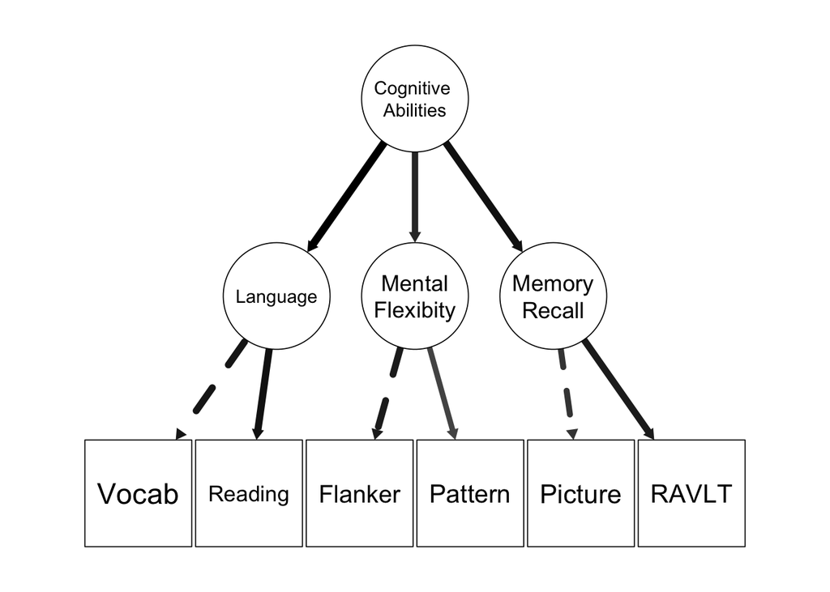

```r
Plabels = c("Vocab","Reading","Flanker","Pattern","Picture","RAVLT","Language","Mental\nFlexibity","Memory\nRecall","Cognitive \nAbilities")
semPlot::semPaths(object=NeuroCog2ndOrder.Fit,intercepts = F, residuals = F,
        whatLabels="no", what = "std", layout="tree", node.width = 1.4,
         edge.label.cex = .6, nodeLabels=Plabels, edge.color="black",
        sizeMan = 10, sizeLat = 10)
```

### 4.0.1 Save the outputs

```r
saveRDS(gfactor_list, paste0(scriptfold,'genetics_psychopathology_common_scan_all_scripts/gfactor_scale_seperate_new', '.RData'))
```